# Problem mit dem Relative Confidence Score (RCS) Ansatz

# 2. Ursachenanalyse: Warum versagt der class-conditional baseline?

## 2.1 Vereinfachtes Beispiel

### Szenario 1: Schlechtes Modell (niedrige dependency)

```r
# 4 Patienten mit "diabetic" als true label
true_labels <- factor(c("diabetic", "diabetic", "diabetic", "diabetic"),
                      levels = c("healthy", "diabetic", "hypertensive"))

# Modell ist schlecht: verrauschte, variable Vorhersagen
predicted_probs_poor <- matrix(
  c(0.40, 0.30, 0.30,  # Patient 1: 0.30 für diabetic
    0.25, 0.60, 0.15,  # Patient 2: 0.60 für diabetic (Ausreisser)
    0.50, 0.35, 0.15,  # Patient 3: 0.35 für diabetic
    0.45, 0.40, 0.15), # Patient 4: 0.40 für diabetic
  ncol = 3, byrow = TRUE,
  dimnames = list(NULL, c("healthy", "diabetic", "hypertensive"))
)

# g_i: Vorhersage für true class
g_i_poor <- predicted_probs_poor[, "diabetic"]

# b_i: Class-conditional baseline (Durchschnitt über alle diabetic-Patienten)
b_i_poor <- mean(g_i_poor)

# r_i: Relative score
r_i_poor <- g_i_poor / b_i_poor

tau <- 1.25

result_poor <- data.frame(
  Patient = 1:4,
  g_i = g_i_poor,
  b_i = b_i_poor,
  r_i = round(r_i_poor, 2),
  at_risk = r_i_poor > tau
)

kable(result_poor, caption = "Schlechtes Modell: Variable Vorhersagen")
```

Schlechtes Modell: Variable Vorhersagen

| Patient | g_i | b_i | r_i | at_risk |
| --- | --- | --- | --- | --- |
| 1 | 0.30 | 0.4125 | 0.73 | FALSE |
| 2 | 0.60 | 0.4125 | 1.45 | TRUE |
| 3 | 0.35 | 0.4125 | 0.85 | FALSE |
| 4 | 0.40 | 0.4125 | 0.97 | FALSE |

**Confidence Rate:** 25%

### Szenario 2: Gutes Modell (hohe dependency)

```r
# Modell ist GUT: präzise und konsistente Vorhersagen
predicted_probs_good <- matrix(
  c(0.05, 0.85, 0.10,  # Patient 1: 0.85 für diabetic
    0.08, 0.87, 0.05,  # Patient 2: 0.87 für diabetic
    0.06, 0.84, 0.10,  # Patient 3: 0.84 für diabetic
    0.07, 0.86, 0.07), # Patient 4: 0.86 für diabetic
  ncol = 3, byrow = TRUE,
  dimnames = list(NULL, c("healthy", "diabetic", "hypertensive"))
)

g_i_good <- predicted_probs_good[, "diabetic"]
b_i_good <- mean(g_i_good)
r_i_good <- g_i_good / b_i_good

result_good <- data.frame(
  Patient = 1:4,
  g_i = g_i_good,
  b_i = round(b_i_good, 3),
  r_i = round(r_i_good, 2),
  at_risk = r_i_good > tau
)

kable(result_good, caption = "Gutes Modell: Konsistente Vorhersagen")
```

Gutes Modell: Konsistente Vorhersagen

| Patient | g_i | b_i | r_i | at_risk |
| --- | --- | --- | --- | --- |
| 1 | 0.85 | 0.855 | 0.99 | FALSE |
| 2 | 0.87 | 0.855 | 1.02 | FALSE |
| 3 | 0.84 | 0.855 | 0.98 | FALSE |
| 4 | 0.86 | 0.855 | 1.01 | FALSE |

**Ergebnis:** Alle Patienten haben ähnliche Vorhersagen → alle `r_i ≈ 1.0` → **niemand at risk**

**Confidence Rate:** 0%

## 2.2 Problematik

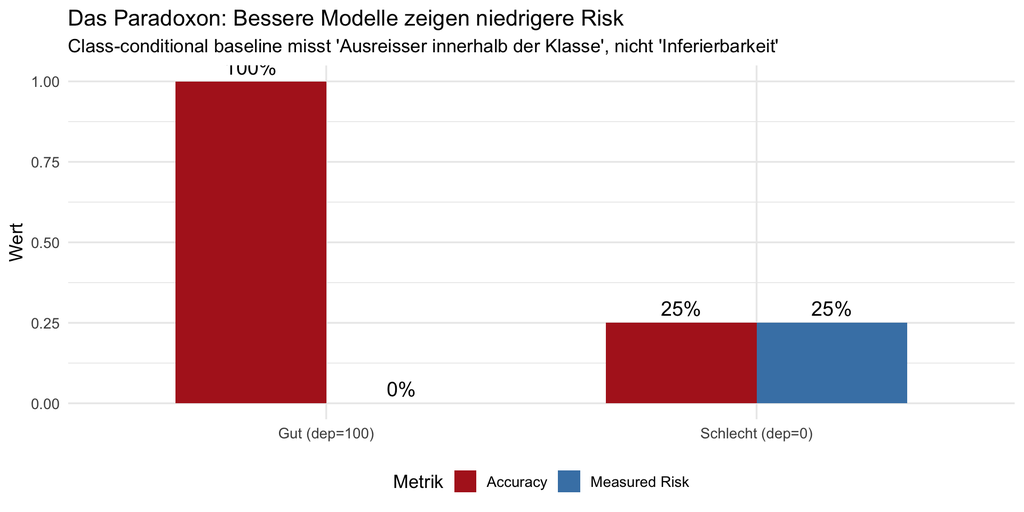

**Warum passiert das?**

Der class-conditional baseline `b_i = mean(g_i | true_class = k)` misst:

> “Ist diese Beobachtung ungewöhnlich im Vergleich zu anderen in derselben Klasse?”

Das ist nicht gleichbedeutend mit:

> “Kann ein Angreifer das Attribut besser als die Basisrate vorhersagen?”

Wenn alle Vorhersagen innerhalb einer Klasse gleich gut sind → keine Ausreisser → `r_i → 1` → niedrige gemessene Risk

Aber tatsächlich: hohe Accuracy = hohe inferential disclosure risk

# 3. Lösung: Marginal Baseline mit normalisierter Verbesserung

## 3.1 Warum Marginal Baseline?

**Zwei mögliche Baselines:**

### Option A: Random Guessing (Uniform)

```r
n_classes <- 3  # healthy, diabetic, hypertensive
baseline_uniform <- 1 / n_classes
cat("Baseline (random guessing):", baseline_uniform, "\n")
```

```
## Baseline (random guessing): 0.3333333
```

### Option B: Marginal Frequencies (aus Original-Daten)

```r
# Realistische Verteilung aus ORIGINAL dataset
# (konsistent mit numerischem Fall: Vergleich mit Original-Werten)
marginal_freq_original <- c(healthy = 0.70, diabetic = 0.18, hypertensive = 0.12)
print(marginal_freq_original)
```

```
##      healthy     diabetic hypertensive
##         0.70         0.18         0.12
```

**Interpretation:** Baseline ist “blind nach Häufigkeit raten”. Wenn das Modell nur diese Basisrate reproduziert, sollte niemand at risk sein.

Wir sollten Option B nehmen, weil sie realistischer ist und korrekt erkennt, wenn die Vorhersagen nicht besser sind als die Original-Basisrate

## 3.2 Problem: Klassenabhängige Threshholds

Mit der einfachen Ratio `r_i = g_i / b_i` (wobei g_i die vorhergesagte Wahrscheinlichkeit für die wahre Klasse ist) bedeutet **derselbe τ-Wert unterschiedliche absolute Anforderungen** für verschiedene Klassen:

**Beispiel mit τ = 1.25:**

- **Healthy** (b=0.70): braucht g_i > 0.875 für r_i > 1.25
- **Diabetic** (b=0.18): braucht g_i > 0.225 für r_i > 1.25

**Das Problem:**

Eine diabetic-Person mit g_i = 0.50 (Modell sagt 50% diabetic - mittelmässige Vorhersage) wird als “at risk” markiert (r_i = 2.78), während eine healthy-Person mit g_i = 0.80 (Modell sagt 80% healthy - bessere Vorhersage!) nicht als “at risk” markiert wird (r_i = 1.14).

Derselbe τ-Schwellenwert bedeutet also unterschiedliche Dinge für verschiedene Klassen. Seltene Klassen haben viel niedrigere absolute Anforderungen, was die Interpretation von τ inkonsistent macht und Vergleche zwischen Klassen unmöglich.

## 3.3 Lösung: Normalisierte Verbesserung

Wir messen die Verbesserung über die Baseline als Anteil der maximal möglichen Verbesserung.

### Formel

$$\text{normalized_gain}_i = \frac{g_i -
b_i}{1 - b_i}$$

where,

- **g_i**: Vorhergesagte Wahrscheinlichkeit für die wahre Klasse
- **b_i**: Baseline aus Original-Daten
- **Zähler (g_i - b_i)**: Absolute Verbesserung
- **Nenner (1 - b_i)**: Maximal mögliche Verbesserung

**Ergebnis:** Ein Wert der angibt ob das Modell signifikant mehr gelernt als nur die Basisrate.

## 3.4 Neuberechnung mit korrigierter Baseline

### Schlechtes Modell mit normalisierter Verbesserung

```r
g_i_poor <- c(0.30, 0.60, 0.35, 0.40)

# True class ist diabetic (baseline aus ORIGINAL = 0.18)
b_i_poor <- rep(0.18, 4)

# Normalisierte Verbesserung
max_improvement <- 1 - b_i_poor  # 0.82 für alle
gain_poor <- (g_i_poor - b_i_poor) / max_improvement

tau_normalized <- 0.3  # 30% Verbesserung erforderlich

result_poor_new <- data.frame(
  Patient = 1:4,
  g_i = g_i_poor,
  baseline_original = b_i_poor,
  normalized_gain = round(gain_poor, 3),
  at_risk = gain_poor > tau_normalized
)

kable(result_poor_new, caption = "Schlechtes Modell mit normalisierter Verbesserung (Baseline aus Original)")
```

Schlechtes Modell mit normalisierter Verbesserung (Baseline aus Original)

| Patient | g_i | baseline_original | normalized_gain | at_risk |
| --- | --- | --- | --- | --- |
| 1 | 0.30 | 0.18 | 0.146 | FALSE |
| 2 | 0.60 | 0.18 | 0.512 | TRUE |
| 3 | 0.35 | 0.18 | 0.207 | FALSE |
| 4 | 0.40 | 0.18 | 0.268 | FALSE |

```r
cat("Confidence Rate:", mean(gain_poor > tau_normalized) * 100, "%\n")
```

```
## Confidence Rate: 25 %
```

### Gutes Modell mit normalisierter Verbesserung

```r
g_i_good <- c(0.85, 0.87, 0.84, 0.86)
b_i_good <- rep(0.18, 4)

gain_good <- (g_i_good - b_i_good) / (1 - b_i_good)

result_good_new <- data.frame(
  Patient = 1:4,
  g_i = g_i_good,
  baseline_original = b_i_good,
  normalized_gain = round(gain_good, 3),
  at_risk = gain_good > tau_normalized
)

kable(result_good_new, caption = "Gutes Modell mit normalisierter Verbesserung (Baseline aus Original)")
```

Gutes Modell mit normalisierter Verbesserung (Baseline aus Original)

| Patient | g_i | baseline_original | normalized_gain | at_risk |
| --- | --- | --- | --- | --- |
| 1 | 0.85 | 0.18 | 0.817 | TRUE |
| 2 | 0.87 | 0.18 | 0.841 | TRUE |
| 3 | 0.84 | 0.18 | 0.805 | TRUE |
| 4 | 0.86 | 0.18 | 0.829 | TRUE |

```r
cat("Confidence Rate:", mean(gain_good > tau_normalized) * 100, "%\n")
```

```
## Confidence Rate: 100 %
```